# 5.4 The Normal Distribution

## Density Curves

We represent the shape of a continuous variable using a **density curve**. This is like a histogram, but with a smooth curve:

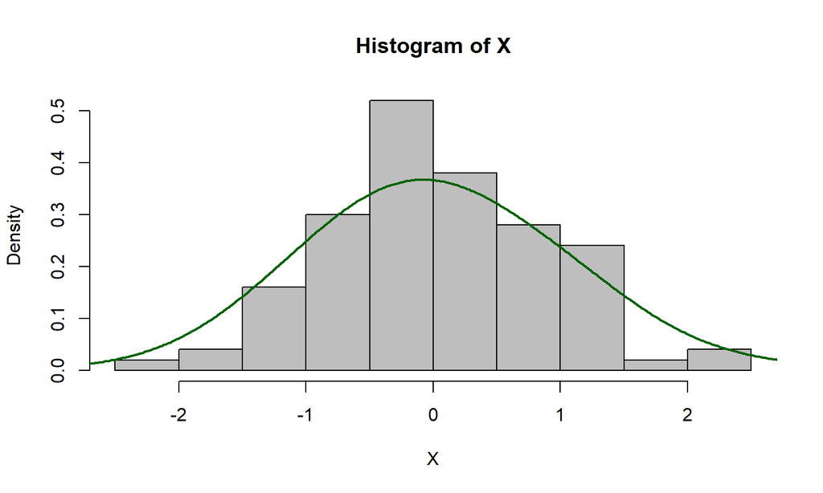

## Density Curves

Properties:

1. The curve is always above the horizontal axis (because probabilities are always nonnegative).
2. The total area under the curve equals 1.

## Density Curves

The proportion of all possible observations that lie within a specified range equals the corresponding area under the density curve.

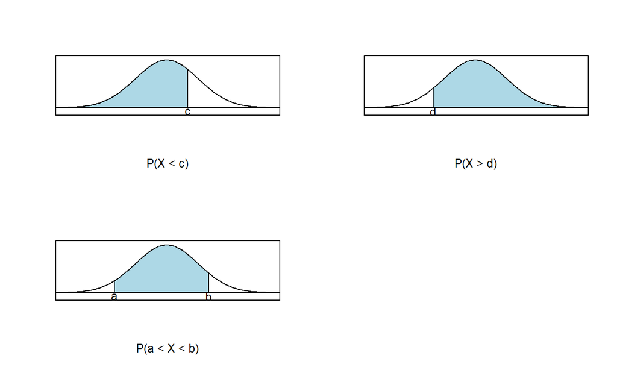

## Normal Curves

- A **normal curve** is a special type of density curve that has a “bell-shaped” distribution.
- A variable is **normally distributed** or has a **normal distribution** if its distribution has the shape of a normal curve.

Why “normal”? Because it appears so often in practice!

## Normal Distributions

Normal distributions…

- are fully determined by parameters mean \(\mu\) and standard deviation \(\sigma\).
- are symmetric and centered at \(\mu\).
- have spreads that depend on \(\sigma\).

## Normal Distributions

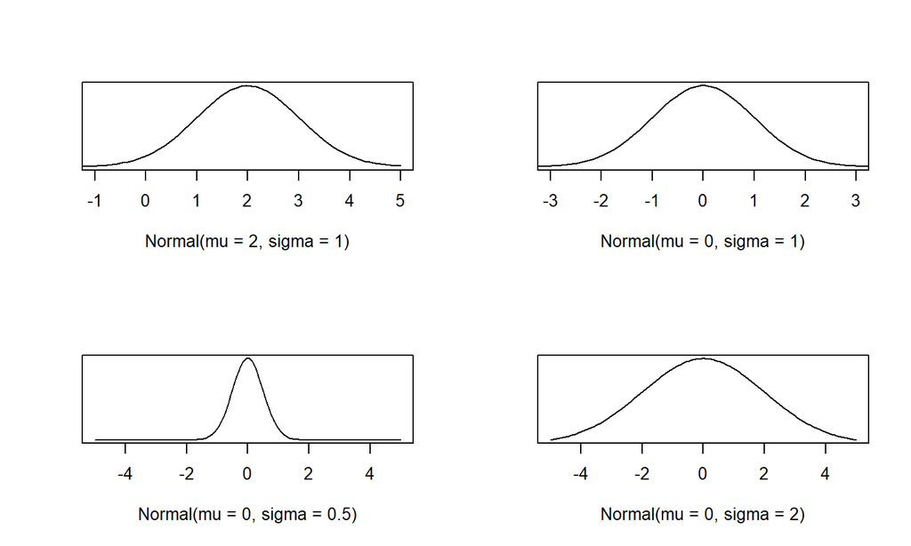

## Normal Distributions

To check whether a variable is (approximately) normally distributed,

1. Check the histogram to see if it is symmetric and bell-shaped.
2. Estimate the parameters: \(\mu\) using \(\bar{x}\) and \(\sigma\) using \(s\).

## Z-Scores

- We standardize a variable using \[z = \frac{x-\mu}{\sigma}.\]
- This is also called a **z-score**.
- Standardizing using this formula will *always* result in a variable with mean 0 and standard deviation 1.
- These are useful for comparing values which are originally on very different scales.

## Note about Z-Scores

A z-score tells us how many standard deviations an observation is from the mean.

- A positive z-score \(z>0\) is *above* the mean.
- A negative z-score \(z<0\) is *below* the mean.

*Example*: \(z=-0.23\) is 0.23 standard deviations below the mean.

## Checkpoint

- ACT scores have mean 20.8 and standard deviation 5.8.
- SAT scores have mean 1500 and standard deviation 300.
- If Jose scored a 27 on his ACT and Alice scored a 1850 on her SAT, who would you say got the better score?

## Empirical Rule for Variables

For any (approximately) normally distributed variable,

1. Approximately 68% of all possible observations lie within one standard deviation of the mean: \(\mu \pm \sigma.\)
2. Approximately 95% of all possible observations lie within two standard deviations of the mean: \(\mu \pm 2\sigma.\)
3. Approximately 99.7% of all possible observations lie within three standard deviations of the mean: \(\mu \pm 3\sigma.\)

## The Standard Normal Distribution

- A **standard normal distribution** is a normal distribution with mean \(\mu=0\) and standard deviation \(\sigma=1\).
- If \(X\) is approximately normal, then the standardized variable \(Z\) will have a standard normal distribution.

Note: when we z-score a variable, we preserve the area under the curve properties!

- If \(X\) is Normal\((\mu,\sigma)\), then \[P(X < c) = P\left(Z < \frac{c - \mu}{\sigma}\right) = P(Z < z).\]